# Statistics 744, McMaster University

# high-dimensional data

Oct 2021

## packages

Some of these packages may be hard to install, i.e. depending on system resources (especially `rggobi`).

```
library(tourr)
## archived: use remotes::install_version("rggobi", "2.1.22")
## or remotes::install_github("ggobi/rggobi")
## see the github repository https://github.com/ggobi/rggobi
## and the ggobi web site: http://ggobi.org/
library(rggobi)
library(factoextra)
library(pheatmap)
library(tidyverse)
```

## Buja, Cook, and Swayne (1996)

- scatterplots (point locations)
- traces (functions: parallel coordinates, [Andrews plots](https://en.wikipedia.org/wiki/Andrews_plot))
- glyphs (stars/radar charts/faces/etc.)

## tasks

- finding gestalt: focusing views (projection)
- posing queries: brushing/linking
- making comparisons: arranging many views

## focusing: animation/motion

- adds a dimension (2D to 3D)
- smoothness/object continuity
- real-time user control: allows user to search/tune

## interactive example

```
ggobi(laser)
```

## tours

three components:

- data matrix (*n* × *p*)
- **tour path** that produces a smooth sequence of projection matrices (*p* × *d*)
- **display method** that renders the projected data.

Goal: allow automated, systematic search through **entire** space of projections

```
animate_xy(laser)
```

## available display methods

```
apropos("animate_")

##  [1] "animate_andrews"   "animate_density2d" "animate_depth"
##  [4] "animate_dist"      "animate_faces"     "animate_groupxy"
##  [7] "animate_image"     "animate_pca"       "animate_pcp"
## [10] "animate_sage"      "animate_scatmat"   "animate_slice"
## [13] "animate_stars"     "animate_stereo"    "animate_trails"
## [16] "animate_xy"
```

## PCA

Examples/data from Holmes and Huber (2019)

- `prcomp` (SVD): preferred (also `princomp` ??)
- same data; projects in a way that (hopefully) focuses on interesting angles in the data
- assumes linear features
- normality not necessary, but better-behaved with normal data

## wine PCA example

```
load("../data/wine.RData")
load("../data/wineClass.RData")

winePCAd = prcomp(wine,scale=TRUE) ## compute PCA
f0 <- fviz_pca_biplot(winePCAd, geom = "point", habillage = wine.class,
                      col.var = "violet", addEllipses = TRUE, ellipse.level = 0.69) +
  ggtitle("") + coord_fixed() +
  scale_colour_brewer(palette="Dark2") +
  scale_fill_brewer(palette="Dark2")
## make augmented data we can use
aug_data <- (get_pca_ind(winePCAd)$coord
  %>% as_tibble()
  %>% mutate(class=wine.class)
)
```

## plot

```
print(f0)
```

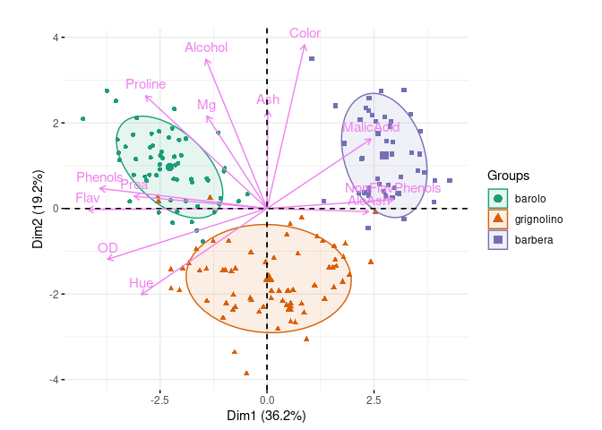

## improved plot

```
f1 <- fviz_pca_biplot(winePCAd, geom = "point", habillage = wine.class,
   col.var = "violet") + ggtitle("") + coord_fixed() +
  scale_colour_brewer(palette="Dark2") +
  scale_fill_brewer(palette="Dark2")
names(ggplot_build(f1)$data[[1]])

##  [1] "colour" "shape"  "x"      "y"      "PANEL"  "group"  "size"   "fill"
##  [9] "alpha"  "stroke"

f2 <- f1 + ggalt::geom_encircle(data=aug_data,
                          aes(x=Dim.1,y=Dim.2,group=class,
                              colour=class,
                              fill=class),alpha=0.2,
                          show.legend=FALSE)
```

```
print(f2)
```

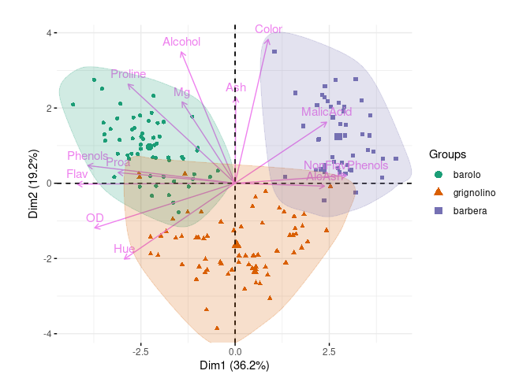

## challenges

- categorical/compositional data
- random forest viz?

## references

Buja, Andreas, Dianne Cook, and Deborah F. Swayne. 1996. “Interactive High-Dimensional Data Visualization.” *Journal of Computational and Graphical Statistics* 5 (1): 78–99. https://doi.org/10.2307/1390754.

Holmes, Susan, and Wolfgang Huber. 2019. *Modern Statistics for Modern Biology*. 1 edition. Cambridge: Cambridge University Press.

Course home page